# Matrices and Images

Matt Hudson

# R Markdown for computer lab class 3, Data Processing and Analysis

## Introduction to R Markdown and images as matrices

(revised 8.2.2022)

The document includes both content (in gray boxes) as well as the output (white boxes) of any embedded R code chunks within the document. You can also copy and paste the code from the gray boxes into your R terminal.

### Revision:

To create a single variable in an object:

```r
scalar_object<-(2+3+4) #make number by adding other numbers
print(scalar_object) #print contents
```

```
## [1] 9
```

```r
typeof(scalar_object) #find how the variables are stored
```

```
## [1] "double"
```

To create a vector

```r
vector_object_1<-c(2,3,4) #make vector, storing numbers separately
print(vector_object_1) #print contents
```

```
## [1] 2 3 4
```

```r
typeof (vector_object_1) #find how the variables are stored
```

```
## [1] "double"
```

… and a second vector

```r
vector_object_2<-c(4,6,8)
print(vector_object_2)
```

```
## [1] 4 6 8
```

```r
typeof (vector_object_2)
```

```
## [1] "double"
```

Plot the vectors against one another, and connect the dots:

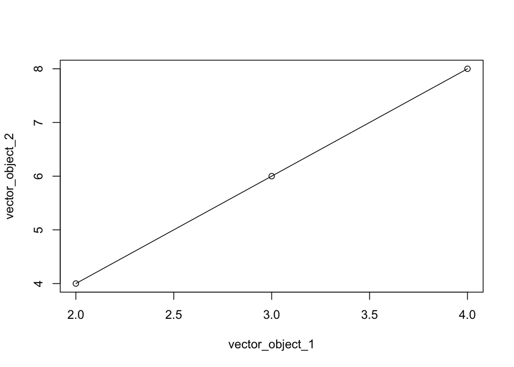

```r
plot(vector_object_1,vector_object_2) #make scatter plot of the values in the two vectors
lines(vector_object_1,vector_object_2) #add lines between points
```

### Today’s Lesson

So what about matrices? Multiple ways of creating a matrix.

First let’s create a third vector, just for symmetry

```r
vector_object_3<-c(1,2,3)
print(vector_object_3)
```

```
## [1] 1 2 3
```

```r
typeof (vector_object_3)
```

```
## [1] "double"
```

Now let’s turn those vectors into a matrix:

First with vectors as columns

```r
col_matrix<-cbind(vector_object_1, vector_object_2, vector_object_3) #create a matrix where the vectors are columns
print(col_matrix)
```

```
##      vector_object_1 vector_object_2 vector_object_3
## [1,]               2               4               1
## [2,]               3               6               2
## [3,]               4               8               3
```

and then as rows

```r
row_matrix<-rbind(vector_object_1, vector_object_2, vector_object_3) #create a matrix where the vectors are rows
print(row_matrix)
```

```
##                 [,1] [,2] [,3]
## vector_object_1    2    3    4
## vector_object_2    4    6    8
## vector_object_3    1    2    3
```

Now let’s say we want to plot vectors from the matrix as a scatter plot. We can plot the columns against one another, using square brackets to call out the vectors by the number of the columns:

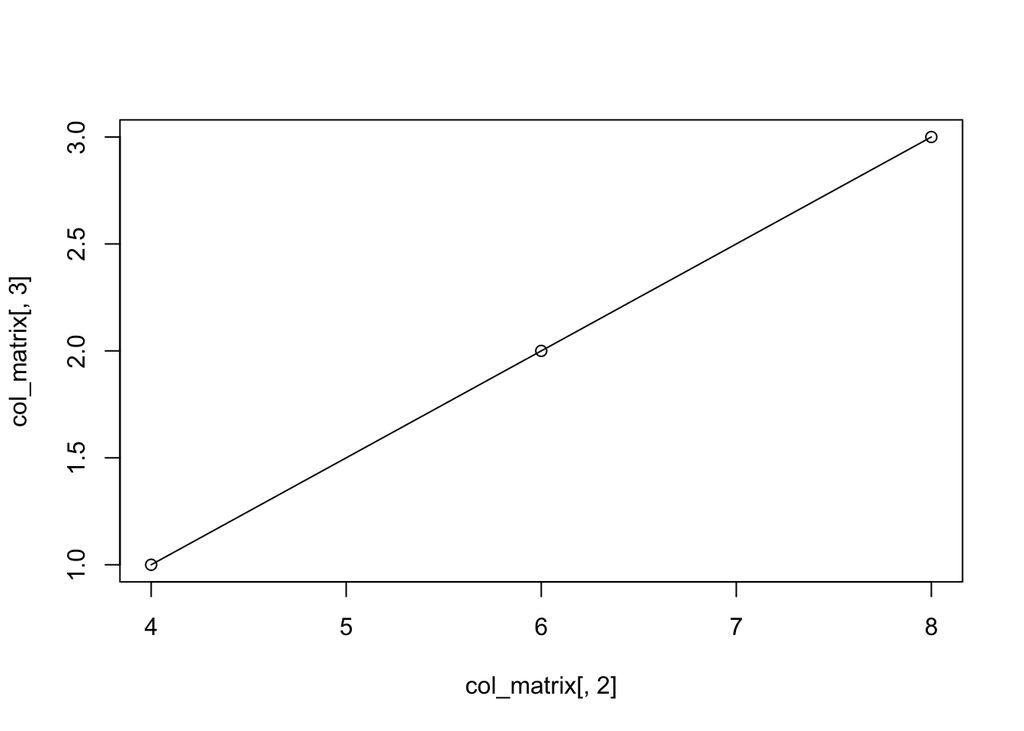

```r
plot(col_matrix[,2], col_matrix[,3]) #by putting the name of the column in square parentheses,
lines(col_matrix[,2], col_matrix[,3]) #you pull it out as a vector
```

Or we can plot the ROWS using a similar process:

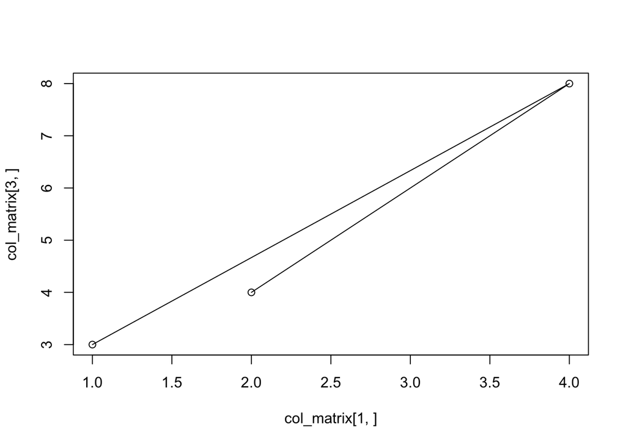

```r
plot(col_matrix[1,], col_matrix[3,]) #by putting the number of the row and a comma in this form [1,]
lines(col_matrix[1,], col_matrix[3,]) #you pull out the row as a vector
```

Or, we can plot the whole matrix at once, as a heatmap

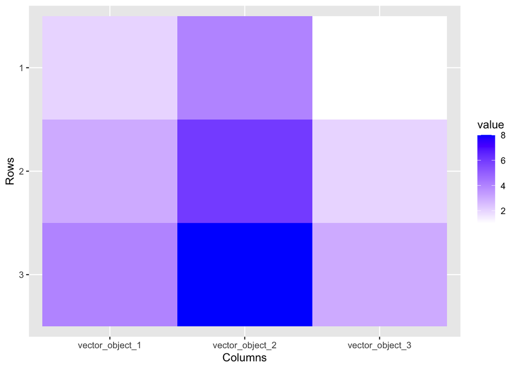

```r
library(ggfortify) #load fancy plotting package
autoplot(col_matrix) #plot heat map of matrix. Used a lot for things like gene expression
```

###Images

Now. This brings us to images, which, as we’ve discussed, are matrices. Imagine we wanted to make a letter out of numbers:

```r
L1<-rep(1, each=8) #make a vector with 8 1s in a row
print (L1)
```

```
## [1] 1 1 1 1 1 1 1 1
```

```r
L2<-rep(0, each=8) #make a vector with 8 0s in a row
L2[8]=1 # turn the last 0 into a 1
L3<-L2 #copy L2 to L3, etc.
L4<-L2
L5<-L2
L_image<-cbind(L1,L2,L3,L4,L5) #convert five vectors to matrix
print (L_image)
```

```
##      L1 L2 L3 L4 L5
## [1,]  1  0  0  0  0
## [2,]  1  0  0  0  0
## [3,]  1  0  0  0  0
## [4,]  1  0  0  0  0
## [5,]  1  0  0  0  0
## [6,]  1  0  0  0  0
## [7,]  1  0  0  0  0
## [8,]  1  1  1  1  1
```

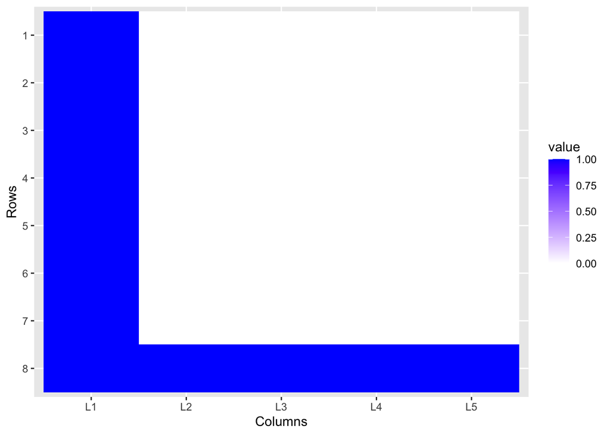

```r
autoplot(L_image) #print as heat map. Look a bit like a letter L? Note high (1) is dark, low (0) is light.
```

So, for this next bit, we’re going to use a non-standard library that lets us import images into R as numeric matrices. If you don’t have this library installed, you will need to run: install.packages(“imager”) library(“imager”) first. Also note that depending on whether you’re on Windows, Linux or Mac, you may need to also install an X11 library such as XQuartz on Mac. Don’t worry too much if you can’t get this to work yourself but just follow along here.

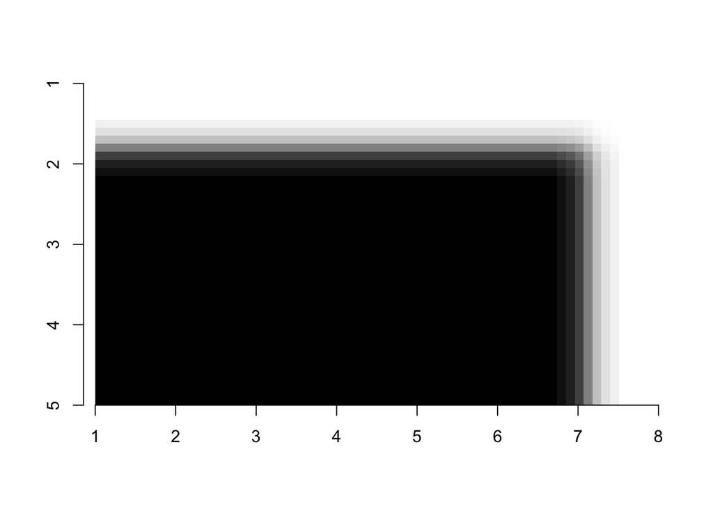

```r
lim<-as.cimg(L_image)
plot(lim)
```

Now, you’ll notice that our letter “L” is now white on black, and the image is flipped both vertically and horizontally. This is because different images represent intensities in different directions, and have different conventions about where to plot each pixel given in the matrix. This library is more representative of how most image systems work (higher numbers are usually brighter, so black=0, white=1), but it varies. Converting image formats can be a pain.

Imager, like many R packages, comes with built-in example data. In this case a color image of boats. Let’s plot this.

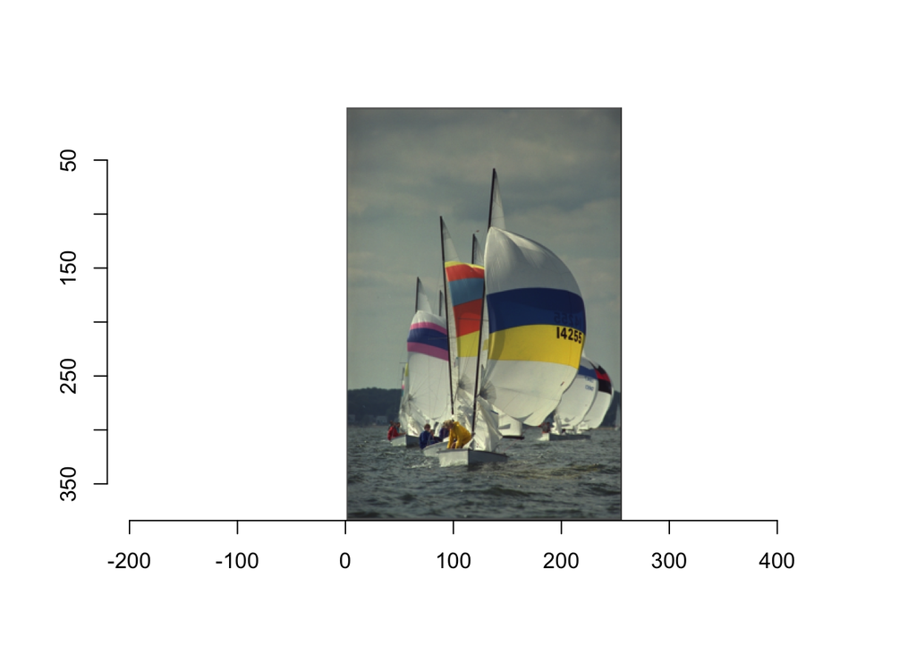

```r
plot(boats) #plot the image matrix
```

So, it’s classed as an image not a numeric data matrix right now, but it’s still numbers:

```r
typeof(boats)
```

```
## [1] "double"
```

```r
head(boats)
```

```
## Image. Width: 6 pix Height: 384 pix Depth: 1 Colour channels: 3
```

```r
mean(boats)
```

```
## [1] 0.5089061
```

So. Now we come to another interesting problem. A color image, as we’ve discussed, has *three* values for each pixel. So that makes a color image a three dimensional matrix (or, if you like, three stacked matrices, one for each color channel). So if we want to convert it into a spreadsheet-type view, we use a *data frame*.

```r
images_as_numbers<-as.data.frame(boats)
head(images_as_numbers)
```

```
##   x y cc     value
## 1 1 1  1 0.3882353
## 2 2 1  1 0.3858633
## 3 3 1  1 0.3849406
## 4 4 1  1 0.3852481
## 5 5 1  1 0.3860388
## 6 6 1  1 0.3855557
```

OK so this bit is a fudge, to change the names of the channels in the image file to something more identifiable (you’ll need to load the dplyr library to do this), and then a fancy plot of the intensities in each channel (you’ll need to install ggplot2 to do this)

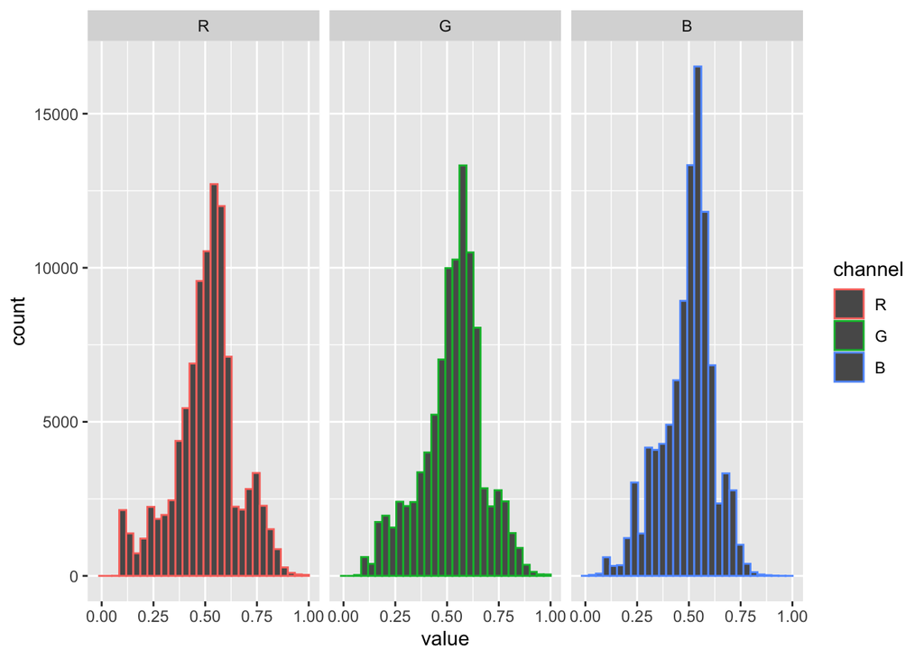

```r
images_as_numbers <- dplyr::mutate(images_as_numbers,channel=factor(cc,labels=c('R','G','B'))) #label R G B layers sequentially
ggplot(images_as_numbers,aes(value,col=channel))+geom_histogram(bins=30)+facet_wrap(~ channel) #do fancy plot
```